# Análisis de dengue en Brasil, Años 2000-2019

Jose García Tácite

2024-03-11

## Introducción a la problemática

El dengue es una enfermedad viral transmitida por la picadura del mosquito Aedes aegypti. Cuando el mosquito se alimenta con sangre de una persona enferma de dengue, y luego pica a otras personas, puede transmitir esta enfermedad. El contagio se produce principalmente por la picadura de los mosquitos infectados, nunca de forma directa de una persona a otra, ni a través de objetos o de la leche materna (Fuente: https://www.argentina.gob.ar/salud/glosario/dengue)

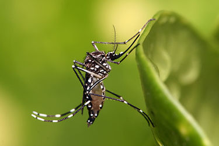

*Aedes aegypti*

En este análisis, se busca interpretar algunos datos registrados durante los años 2000 y 2019 en Brasil. La base de datos fue obtenida en Kaggle (https://www.kaggle.com/datasets/raomuhammadsaeedali/brazil-dengue-dataset-2000-2019).

### Pre-procesamiento

#### Establecimiento de directorio de trabajo, carga de archivo .csv y librerías para manipulación y gráfico de datos

#### Limpieza:

1. Selección de columnas y creación de df: state_name, region_name, biome_name, ecozone_name, main_climate, month, year, dengue_cases, population, pop_density, tmax, tmin, urban, water_network, water_shortage

```r
dengue <- dengue_brasil %>%
  select(state_name, region_name, biome_name, ecozone_name, main_climate, month, year, dengue_cases, population, pop_density, tmax, tmin, urban, water_network, water_shortage)
```

2. Reemplazo de abreviaturas de climas por descripciones

```r
dengue$main_climate <- gsub("AF", "Clima tropical lluvioso",dengue$main_climate)
dengue$main_climate <- gsub("AM", "Clima tropical monzonico",dengue$main_climate)
dengue$main_climate <- gsub("AS", "Clima tropical de sabana",dengue$main_climate)
dengue$main_climate <- gsub("AW", "Clima tropical de sabana con estacion seca corta",dengue$main_climate)
dengue$main_climate <- gsub("BSH", "Clima seco subtropical",dengue$main_climate)
dengue$main_climate <- gsub("CFA", "Clima subtropical humedo",dengue$main_climate)
dengue$main_climate <- gsub("CFB", "Clima subtropical humedo con verano templado",dengue$main_climate)
dengue$main_climate <- gsub("CWA", "Clima subtropical humedo con invierno seco",dengue$main_climate)
dengue$main_climate <- gsub("CWB", "Clima subtropical humedo con invierno seco y verano calido",dengue$main_climate)
```

3. Eliminación de filas con valores no disponibles o vacíos (NA)

```r
dengue <- na.omit(dengue)
```

### Análisis exploratorio

#### ¿Cuántos casos de dengue se han reportado en Brasil desde 2000 a 2019?

```r
sum(dengue$dengue_cases)
```

```
## [1] 12895293
```

#### Distribución de casos de dengue por estado

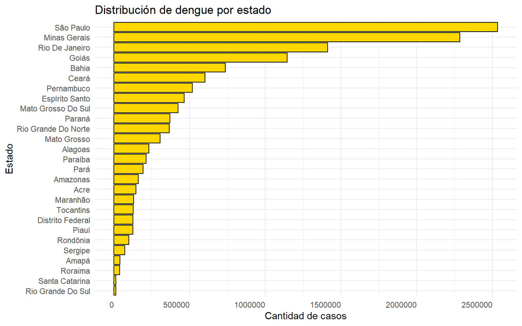

```r
# Generar dataframe
dengue_estados <- as.data.frame(dengue %>%
  group_by(state_name) %>%
  summarise(casos_estado = sum(dengue_cases)) %>%
  arrange(-casos_estado) %>%
  mutate(state_name = fct_reorder(state_name, casos_estado)) )


# Graficar
ggplot(data= dengue_estados, aes(x= casos_estado, y = state_name))+
  geom_col(fill= 'gold', color= 'black')+
  labs(title = 'Distribución de dengue por estado',
       x = 'Cantidad de casos',
       y = 'Estado')+
  theme_minimal()+
  theme(axis.text.x = element_text(angle = 0, hjust = 1))
```

*¿Cuáles son los estados con más casos?*

[figure not shown]

```r
casos_max_dengue_estado <- dengue_estados %>%
  group_by(state_name) %>%
  arrange(-casos_estado) %>%
  head()


ggplot(casos_max_dengue_estado, aes(x=state_name, y=casos_estado)) +
  geom_bar(stat="identity", fill = 'indianred', color = 'black') +
  labs(title= 'Cinco estados con más casos',x = "Estado", y = "Cantidad de casos de dengue")+
  theme_minimal()
```

*¿Cuáles son los estados con menos casos?*

[figure not shown]

```r
casos_min_dengue_estado <- dengue_estados %>%
  group_by(state_name) %>%
  arrange(-casos_estado) %>%
  tail()



ggplot(casos_min_dengue_estado, aes(x=state_name, y=casos_estado)) +
  geom_bar(stat="identity", fill = 'darkgreen', color = 'black') +
  labs(title= 'Cinco estados con menos casos',x = "Estado", y = "Cantidad de casos de dengue")+
  theme_minimal()
```

#### Distribución de casos de dengue por región

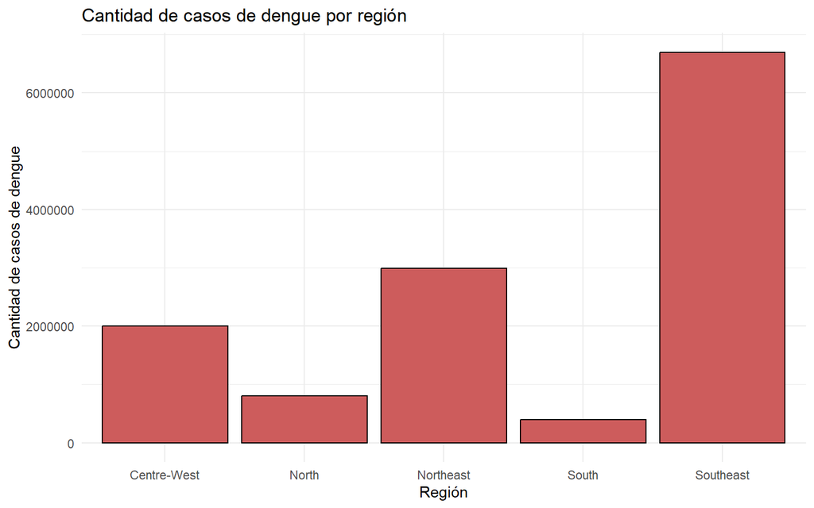

```r
dengue_region <- dengue %>%
  group_by(region_name) %>%
  summarise(dengue_region = sum(dengue_cases)) %>%
  arrange(-dengue_region)

# Desactivar notación científica
options(scipen=999)


ggplot(data = dengue_region, aes(x=region_name, y=dengue_region))+
  geom_bar(stat="identity", fill='indianred', color = 'black')+
  labs(title= 'Cantidad de casos de dengue por región', x="Región", y="Cantidad de casos de dengue")+
  theme_minimal()
```

*¿Cómo quedaría, entonces, la distribución de casos por estado y región?*

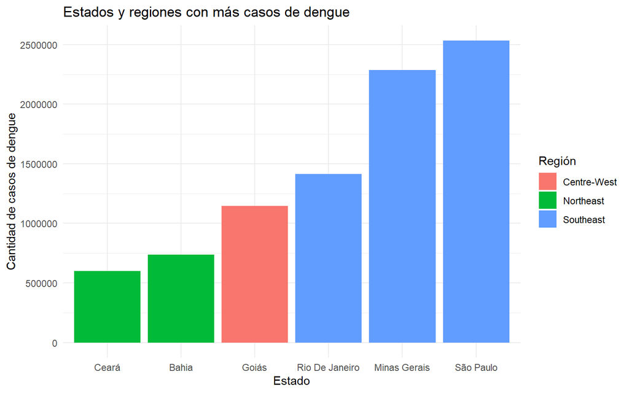

```r
dengue_estado_region_max <- dengue %>%
  group_by(state_name,region_name) %>%
  summarise(total_casos = sum(dengue_cases), .groups = "drop") %>%
  mutate(state_name = fct_reorder(state_name, total_casos)) %>%
  arrange(-total_casos) %>%
  head()

ggplot(data = dengue_estado_region_max, aes(x=state_name, y=total_casos, fill = region_name))+
  geom_bar(stat='identity')+
  labs(title= 'Estados y regiones con más casos de dengue', x="Estado", y="Cantidad de casos de dengue", fill= 'Región')+
  theme_minimal()
```

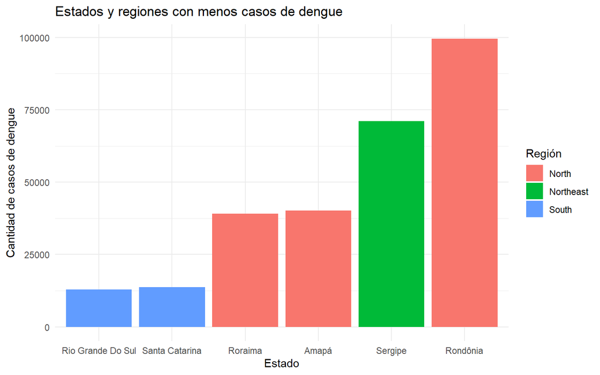

```r
dengue_estado_region_min <- dengue %>%
  group_by(state_name,region_name) %>%
  summarise(total_casos = sum(dengue_cases), .groups="drop") %>%
  arrange(-total_casos) %>%
  mutate(state_name = fct_reorder(state_name, total_casos)) %>%
  tail()


ggplot(data = dengue_estado_region_min, aes(x=state_name, y=total_casos, fill = region_name))+
  geom_bar(stat='identity')+
  labs(title= 'Estados y regiones con menos casos de dengue', x="Estado", y="Cantidad de casos de dengue", fill= 'Región')+
  theme_minimal()
```

#### Distribución de dengue según condiciones climáticas

##### **Clima principal**

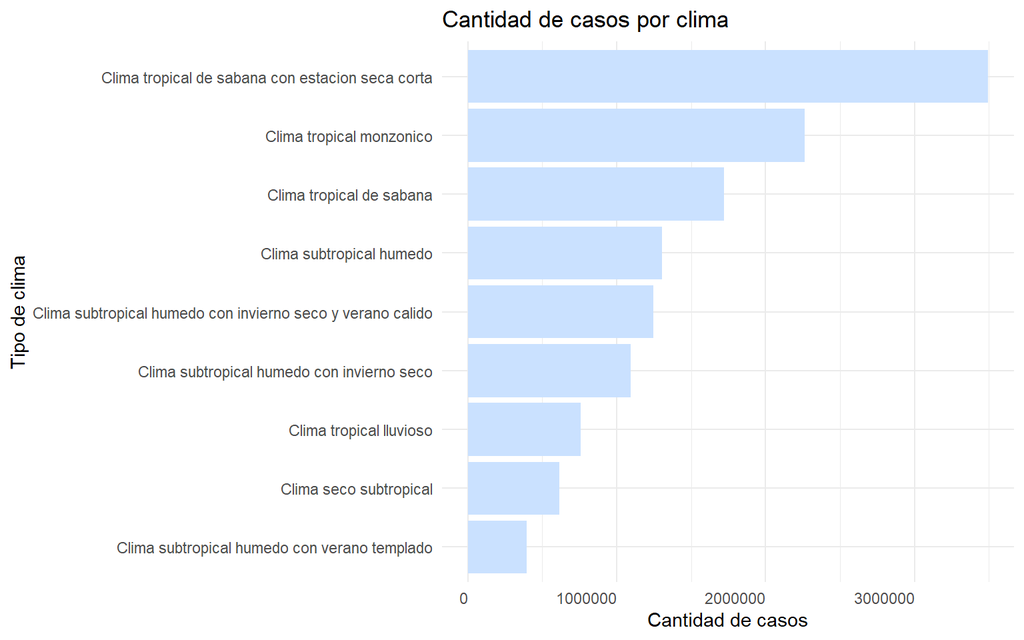

```r
casos_dengue_climas <- dengue %>%
  group_by(main_climate) %>%
  summarise(casos_clima = sum(dengue_cases)) %>%
  arrange(-casos_clima) %>%
  mutate(main_climate = fct_reorder(main_climate, casos_clima))


ggplot(casos_dengue_climas, aes(x= casos_clima ,y=main_climate))+
  geom_bar(stat="identity",fill="lightsteelblue1")+
  labs(title = 'Cantidad de casos por clima', x = 'Cantidad de casos' , y = 'Tipo de clima')+
  theme_minimal()+
  theme(axis.text.x = element_text(angle = 0, hjust = 1))
```

##### **Temperaturas**

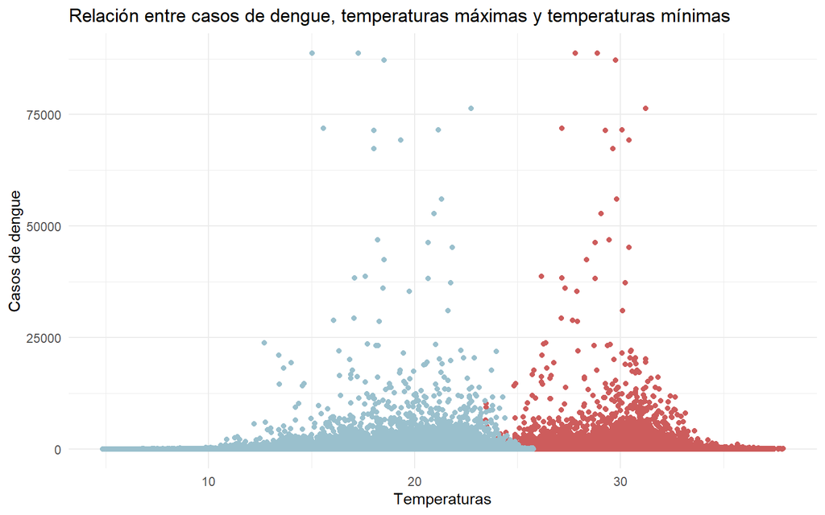

```r
dengue_temp <- dengue %>%
  group_by(main_climate,tmax,tmin) %>%
  summarise(total_casos = sum(dengue_cases), .groups="drop") %>%
  arrange(-total_casos)


dengue_temp_head<- dengue_temp %>%
  head()


ggplot(dengue_temp, aes(x=tmax,y=total_casos))+
  geom_point(color='indianred')+
  geom_point(aes(x=tmin), color = 'lightblue3')+
  labs(title = 'Relación entre casos de dengue, temperaturas máximas y temperaturas mínimas', x = 'Temperaturas', y = 'Casos de dengue') +
  theme_minimal()
```

#### Distribución según índice de urbanismo y cantidad de población

##### **Urbanismo**

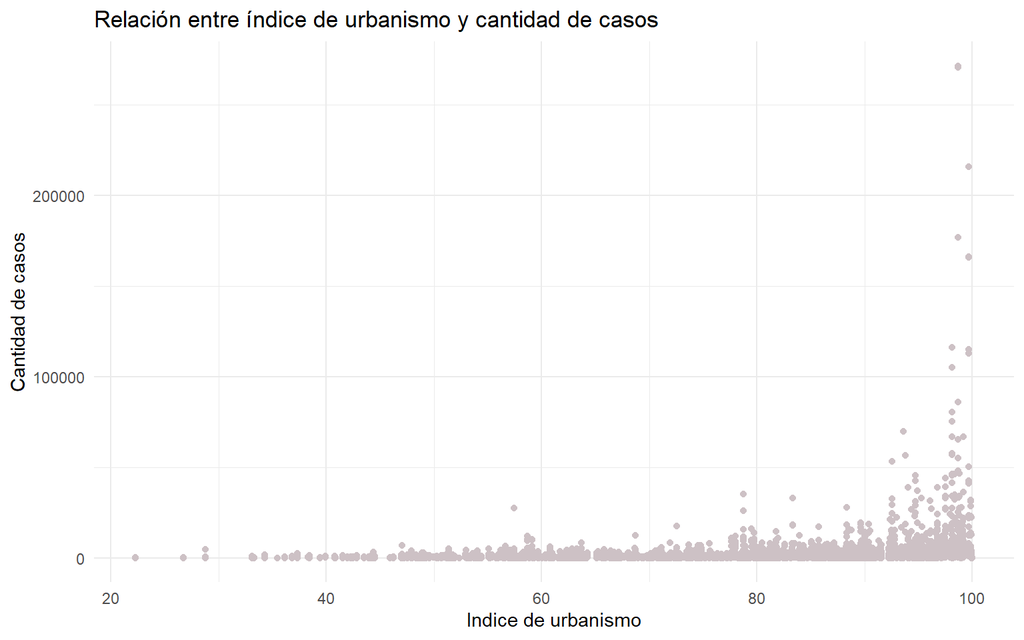

```r
dengue_urb <- dengue %>%
  select(state_name,dengue_cases,population,urban) %>%
  group_by(urban,population) %>%
  summarise(casos_urb = sum(dengue_cases), .groups = "drop") %>%
  arrange(-casos_urb)


grafico_urb <- ggplot(dengue_urb,aes(x=urban, y=casos_urb))+
  geom_point(color='lavenderblush3')+
  labs(title = 'Relación entre índice de urbanismo y cantidad de casos', x= 'Indice de urbanismo', y = 'Cantidad de casos')+
  theme_minimal()

grafico_urb
```

*Correlación entre índice de urbanismo y cantidad de casos*

```r
correlacion_urb<- dengue %>%
  select(dengue_cases,urban)


correlacion_urb <- cor(correlacion_urb)
```

##### **Cantidad de población**

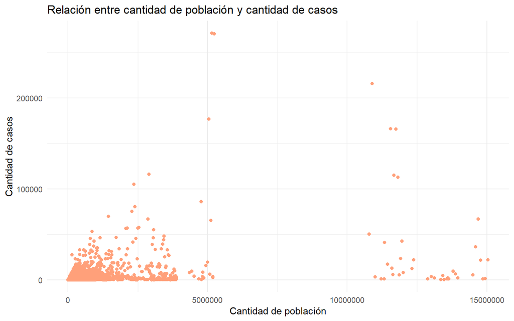

```r
dengue_pobl <- dengue %>%
  select(state_name,dengue_cases,population,pop_density) %>%
  group_by(population) %>%
  summarise(casos_pobl = sum(dengue_cases)) %>%
  arrange(-casos_pobl)


ggplot(dengue_pobl,aes(x=population, y=casos_pobl))+
  geom_point(color='lightsalmon')+
  labs(title = 'Relación entre cantidad de población y cantidad de casos', x= 'Cantidad de población', y = 'Cantidad de casos')+
  theme_minimal()
```

*Correlación entre cantidad poblacional y cantidad de casos*

```r
correlacion_pobl<- dengue %>%
  select(dengue_cases,population)


correlacion_pobl <- cor(correlacion_pobl)
```

#### Exploración con respecto a disponibilidad de agua corriente

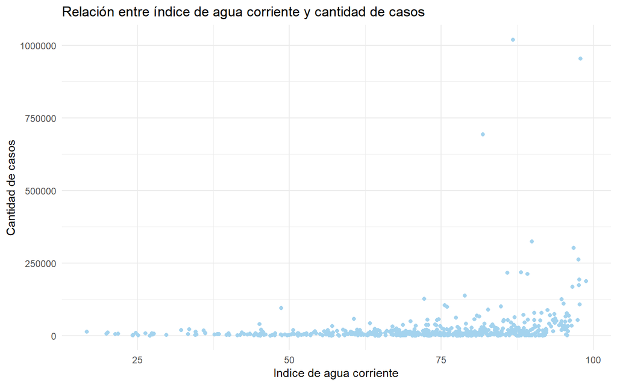

```r
dengue_agua <- dengue %>%
  select(state_name,dengue_cases,water_network) %>%
  group_by(state_name,water_network) %>%
  summarise(casos = sum(dengue_cases), .groups = "drop") %>%
  arrange(-casos)

grafico_agua <- ggplot(dengue_agua,aes(x=water_network,y=casos))+
  geom_point(color = 'lightskyblue2')+
  labs(title = 'Relación entre índice de agua corriente y cantidad de casos', x= 'Indice de agua corriente', y = 'Cantidad de casos')+
  theme_minimal()

grafico_agua
```

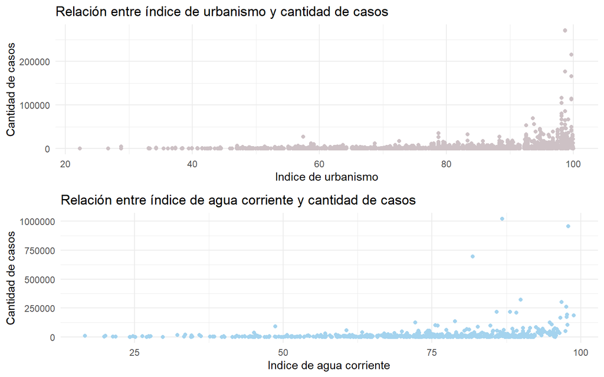

```r
grid.arrange(grafico_urb,grafico_agua, nrow=2)
```

Los gráficos que indican la relación entre casos y urbanismo, y casos y agua corriente son bastante parecidos.

#### Exploración por tendencias temporales

*¿Cómo han variado los casos de dengue a lo largo del tiempo?*

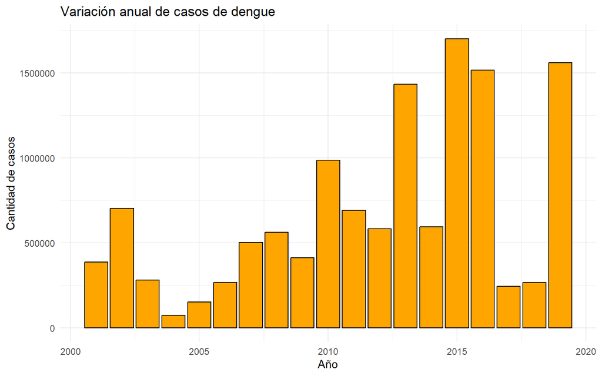

```r
dengue_anual <- dengue %>%
  group_by(year) %>%
  summarise(casos_anuales = sum(dengue_cases)) %>%
  arrange(-casos_anuales)

ggplot(dengue_anual,aes(x=year,y=casos_anuales))+
  geom_bar(stat="identity", fill = 'orange', color = 'black')+
  labs(title = "Variación anual de casos de dengue", x = 'Año', y = 'Cantidad de casos')+
  theme_minimal()
```

*¿Existen patrones estacionales en la incidencia de casos de dengue?*

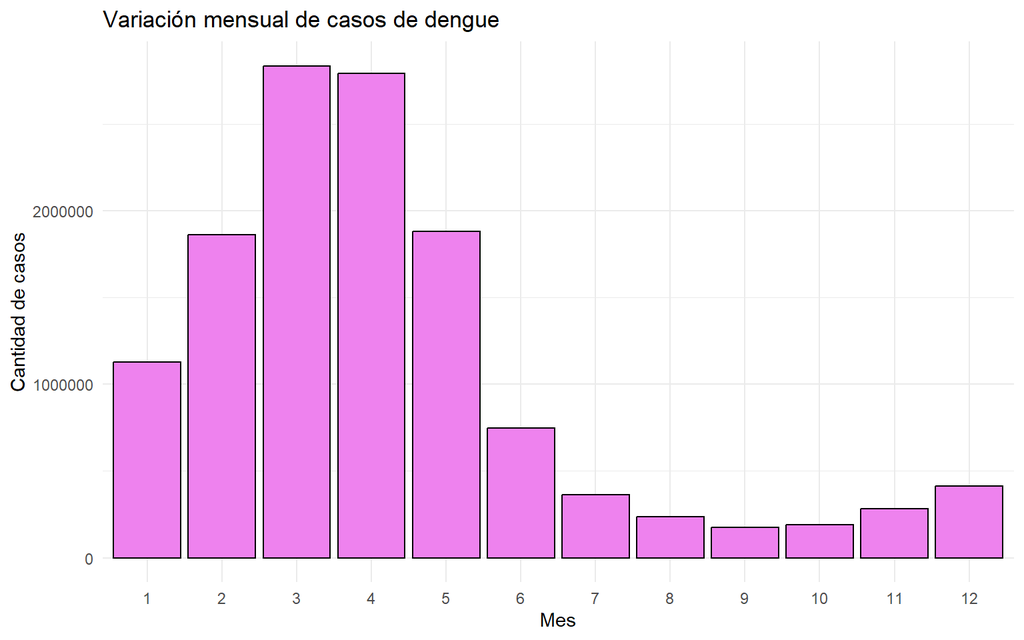

```r
dengue_mensual <- dengue %>%
  group_by(month) %>%
  summarise(casos_mensuales = sum(dengue_cases)) %>%
  arrange(-casos_mensuales)


ggplot(dengue_mensual,aes(x=factor(month),y=casos_mensuales))+
  geom_bar(stat="identity", fill = 'violet', color = 'black')+
  labs(title = "Variación mensual de casos de dengue", x = 'Mes', y = 'Cantidad de casos')+
  theme_minimal()
```

Los meses de marzo, abril y mayo son los que más casos presentaron.

*¿En qué mes y año se presentaron más casos y menos casos?*

```r
dengue_mes_año <- dengue %>%
  group_by(month, year) %>%
  summarise(total_casos = sum(dengue_cases), .groups = "drop") %>%
  arrange(-total_casos)
```

Más casos:

```r
head(dengue_mes_año)
```

```
## # A tibble: 6 × 3
##   month  year total_casos
##   <dbl> <dbl>       <dbl>
## 1     3  2013      424700
## 2     4  2015      405538
## 3     5  2019      400662
## 4     3  2015      398978
## 5     3  2016      392155
## 6     2  2016      385568
```

Menos casos:

```r
tail(dengue_mes_año)
```

```
## # A tibble: 6 × 3
##   month  year total_casos
##   <dbl> <dbl>       <dbl>
## 1    10  2005        3911
## 2     6  2004        3757
## 3     7  2004        2605
## 4     8  2004        2217
## 5    10  2004        2133
## 6     9  2004        1618
```

#### Identificación de posibles factores de riesgo

##### ¿Qué factores parecen estar más asociados con un mayor número de casos de dengue?

```r
dengue_matriz <- dengue %>%
  select(dengue_cases:water_shortage)

matriz_correlacion <- cor(dengue_matriz)
```

### Conclusiones

##### Entonces, ¿se pueden identificar posibles factores de riesgo que contribuyan a la propagación del dengue en ciertas regiones o estados?

```r
dengue_regiones_estados <- dengue %>%
  select(population,pop_density,urban,state_name,region_name) %>%
  group_by(state_name) %>%
  arrange(-population) %>%
  distinct(state_name, region_name)
```